# RNA-Seq Data Visualization in R

Cihan Erkut

April 1, 2019

# 1 Preparations

In this tutorial we go step by step over the RNA-Seq analysis class, which was covered as part of the de.NBI course on March 28, 2019.

We are going to use the RNA-Seq count data from a recent publication [1]. The data was made publicly available on the Gene Expression Omnibus with the accession number GSE121843. You can download the data file `GSE121843_all_counts.txt.gz` at the bottom of the record page and uncompress it, or you can download it from this GitLab page.

First of all, you need to to save the data file into a directory that you know, and run the following command:

```r
setwd("<path>")
```

where you exchange `<path>` with the complete location of that folder.

Next, we need to install Bioconductor because the main package, DESeq2 [2], is deposited there.

```r
if (!requireNamespace("BiocManager"))
    install.packages("BiocManager")
BiocManager::install()
```

Now we can install other packages:

```r
BiocManager::install(c("DESeq2", "biomaRt", "vsn", "IHW"))
install.packages(c("stringi", "pheatmap", "hexbin"))
```

When all installations are done, you have to load these packages via calling the `library` command.

You can speed up your analysis if you use multithreading. However, it may not be available in some systems. You need to try. Here I register 4 cores as my computer has that many.

```r
register(MulticoreParam(4))
```

# 2 Creating data structure

Now, you load the data file:

```r
table_counts <- read.delim(
  file = "GSE121843_all_counts.txt",
  sep = "\t",
  as.is = TRUE
)

table_counts
```

```
## # A tibble: 60,502 x 11
##    gene_id dmso_a dmso_b thz500_a thz500_b thz100_a thz100_b
##    <chr>    <int>  <int>    <int>    <int>    <int>    <int>
##  1 ENSG00…   2884   1912     3301     2664     2586     2905
##  2 ENSG00…      0      0        0        0        0        0
##  3 ENSG00…   4820   2933     3245     2572     3616     4027
##  4 ENSG00…    282    158       85       63      204      255
##  5 ENSG00…   1085    756      466      412      923     1101
##  6 ENSG00…      0      0        0        0        0        0
##  7 ENSG00…   3408   1993     3910     3313     2775     3095
##  8 ENSG00…   6574   4304     7388     6219     5972     6498
##  9 ENSG00…   1700   1117      736      640     1357     1726
## 10 ENSG00…   2668   1696      924      763     2412     2667
## # … with 60,492 more rows, and 4 more variables: actinomycin150_a <int>,
## #   actinomycin150_b <int>, actinomycin10_a <int>, actinomycin10_b <int>
```

The data provided in this file is raw count data. We can construct the count matrix with it. Don’t forget that the first column of `table_counts` is the gene IDs, which we don’t want to include into the counts matrix as data, but we will use them as the rownames of the matrix.

```r
matrix_counts <- data.matrix(table_counts[, -1])
rownames(matrix_counts) <- table_counts$gene_id

head(matrix_counts)
```

```
##                    dmso_a dmso_b thz500_a thz500_b thz100_a thz100_b
## ENSG00000000003.14   2884   1912     3301     2664     2586     2905
## ENSG00000000005.5       0      0        0        0        0        0
## ENSG00000000419.12   4820   2933     3245     2572     3616     4027
## ENSG00000000457.13    282    158       85       63      204      255
## ENSG00000000460.16   1085    756      466      412      923     1101
## ENSG00000000938.12      0      0        0        0        0        0
##                    actinomycin150_a actinomycin150_b actinomycin10_a
## ENSG00000000003.14             3047             3875            3005
## ENSG00000000005.5                 0                0               0
## ENSG00000000419.12             2291             2708            3619
## ENSG00000000457.13               92               87             244
## ENSG00000000460.16              391              420             842
## ENSG00000000938.12                1                1               0
##                    actinomycin10_b
## ENSG00000000003.14            2066
## ENSG00000000005.5                0
## ENSG00000000419.12            2177
## ENSG00000000457.13             164
## ENSG00000000460.16             557
## ENSG00000000938.12               0
```

We also have to create the so-called `coldata`, which contains the matching between count matrix and sample information.

```r
table_samples <- as.data.frame(
  stri_split(
    str = colnames(matrix_counts),
    fixed = "_",
    simplify = TRUE
  )
)

colnames(table_samples) <- c("Treatment", "Replicate")
rownames(table_samples) <- colnames(matrix_counts)

table_samples
```

```
## # A tibble: 10 x 2
##    Treatment      Replicate
##    <fct>          <fct>
##  1 dmso           a
##  2 dmso           b
##  3 thz500         a
##  4 thz500         b
##  5 thz100         a
##  6 thz100         b
##  7 actinomycin150 a
##  8 actinomycin150 b
##  9 actinomycin10  a
## 10 actinomycin10  b
```

Since we want to use DMSO as the control treatment for all other treatments, we have to relevel the `Treatment` factor accordingly.

```r
table_samples$Treatment <- relevel(factor(table_samples$Treatment), "dmso")
```

Now we are ready to build the data structure.

A `DESeqDataSet` object requires the following 3 data:

- `countData`: The count matrix
- `colData`: Sample information
- `design`: Statistical model

Statistical model contains the factors to be evaluated from the gene expression data. In other terms, it is the grouping variable for our experiment. Here, we have only one grouping variable, which is the `Treatment`. Using R’s *formula* data structure, we provide this information as `~Treatment`.

```r
dds <- DESeqDataSetFromMatrix(
  countData = matrix_counts,
  colData = table_samples,
  design = ~Treatment
)

dds
```

```
## class: DESeqDataSet
## dim: 60502 10
## metadata(1): version
## assays(1): counts
## rownames(60502): ENSG00000000003.14 ENSG00000000005.5 ...
##   N_noFeature N_unmapped
## rowData names(0):
## colnames(10): dmso_a dmso_b ... actinomycin10_a actinomycin10_b
## colData names(2): Treatment Replicate
```

Now that we put all our data into a DESeq2 data structure, we can focus on doing some cleaning improvements before we continue with differential expression analysis.

Please compare the size of the `dds` object to see how many genes were removed this way.

```r
dds <- dds[rowSums(counts(dds)) > 5, ]

dds
```

```
## class: DESeqDataSet
## dim: 27446 10
## metadata(1): version
## assays(1): counts
## rownames(27446): ENSG00000000003.14 ENSG00000000419.12 ...
##   N_noFeature N_unmapped
## rowData names(0):
## colnames(10): dmso_a dmso_b ... actinomycin10_a actinomycin10_b
## colData names(2): Treatment Replicate
```

There are some entries in the data set which do not correspond to genes. This data set is annotated using Ensembl gene IDs, which look like `ENSG00000000003.14`. However, there are some entries with names such as `N_unmapped`. These are artefacts of the upstream pipeline and must be removed.

```r
tail(rownames(dds))
```

```
## [1] "ENSG00000282787.1" "ENSG00000282815.1" "N_ambiguous"
## [4] "N_multimapping"    "N_noFeature"       "N_unmapped"
```

We can remove them via selecting the rows that are named in an Ensemble gene ID pattern.

```r
dds <- dds[stri_detect(rownames(dds), fixed = "ENSG"), ]

tail(rownames(dds))
```

```
## [1] "ENSG00000282502.1" "ENSG00000282508.1" "ENSG00000282556.1"
## [4] "ENSG00000282774.1" "ENSG00000282787.1" "ENSG00000282815.1"
```

The gene annotation used in this dataset includes the version information for an Ensembl gene record. That’s why the gene IDs have a period (`.`) at the end, followed by a number.

In the next step, we want to update the gene information from a BioMart service, and this version info is incompatible with it. Therefore we want to remove it at this stage as well.

We use a *regular expression* for this purpose. You can read more about regular expressions [here](https://stringr.tidyverse.org/articles/regular-expressions.html).

We apply the splitting to gene IDs and keep the results in a new character vector.

```r
gene_ids_all <- unlist(
  stri_split(
    str = rownames(dds),
    regex = "\\.\\d*", # pattern is dot (.) followed by some number
    omit_empty = TRUE
  )
)

head(gene_ids_all)
```

```
## [1] "ENSG00000000003" "ENSG00000000419" "ENSG00000000457" "ENSG00000000460"
## [5] "ENSG00000000971" "ENSG00000001036"
```

Next, we search for gene names in Ensembl database for the gene IDs we have.

```r
mart <- useMart(
  biomart = "ensembl",
  dataset = "hsapiens_gene_ensembl"
)

annotations <- getBM(
  attributes = c("ensembl_gene_id", "external_gene_name", "gene_biotype"),
  filters = "ensembl_gene_id",
  values = gene_ids_all,
  mart = mart
)
```

Usually, there are some records that don’t have a match in the database. The query results `NA` for those, which we cannot use as a gene name. In this step, we find those records and use their Ensembl gene IDs as a unique descriptor.

```r
gene_ids_matched <- annotations$ensembl_gene_id
gene_names_matched <- annotations$external_gene_name

gene_names <- gene_names_matched[match(gene_ids_all, gene_ids_matched)]

table(!is.na(gene_names))
```

```
##
## FALSE  TRUE
##   374 27068
```

```r
nonmatching_genes <- which(is.na(gene_names))
gene_names[nonmatching_genes] <- gene_ids_all[nonmatching_genes]

table(!is.na(gene_names))
```

```
##
##  TRUE
## 27442
```

Finally, we update the versioned Ensembl gene IDs with gene names in rownames of the `dds` object.

```r
rownames(dds) <- gene_names
```

# 3 Differential expression analysis

In this section, we will perform the DE analysis on our data set.

The hardest part is over, we created the data structure. Now `DESeq` command can take it and do all statistical analysis on it.

```r
dds <- DESeq(dds, parallel = TRUE)
```

First thing after you run the `DESeq` command must be visualizing dispersion estimates. A plot such as the following means you are good to go:

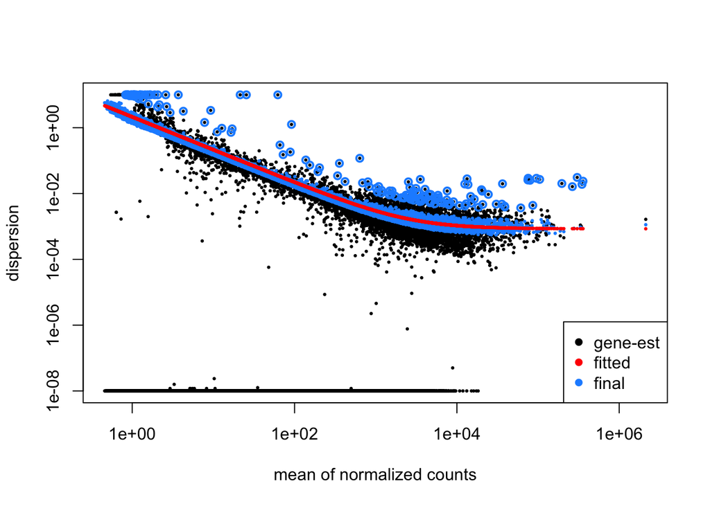

```r
plotDispEsts(dds)
```

Now we want to visualize some basic properties of our data. We will do principal component analysis and hierarchical clustering for this purpose. Both methods require normalized, variance-stabilized data. DESeq2 provides an `rlog` function to perform *regularized log transformation* which does both.

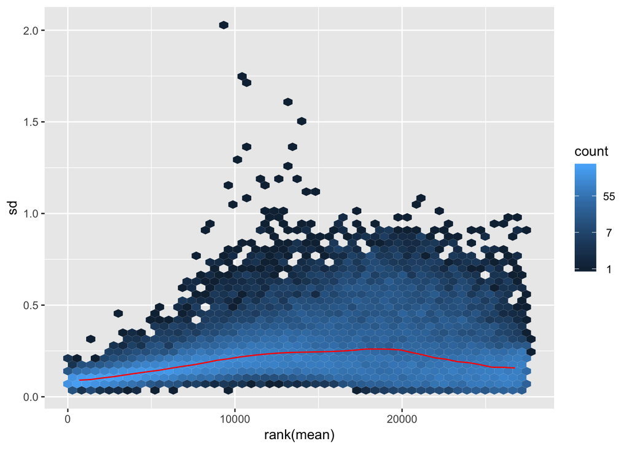

```r
dds_rlog <- rlog(dds)
matrix_counts_rlog <- assay(dds_rlog)
meanSdPlot(matrix_counts_rlog)
```

A PCA will show us similarity between samples. DESeq2 has a nice `plotPCA` command which abstracts away all the details to perform a PCA in R. It also plots the results nicely. You only have to define *interesing groups* using the `intgroup` parameter. Since our data set has only one group, *treatment*, we define that.

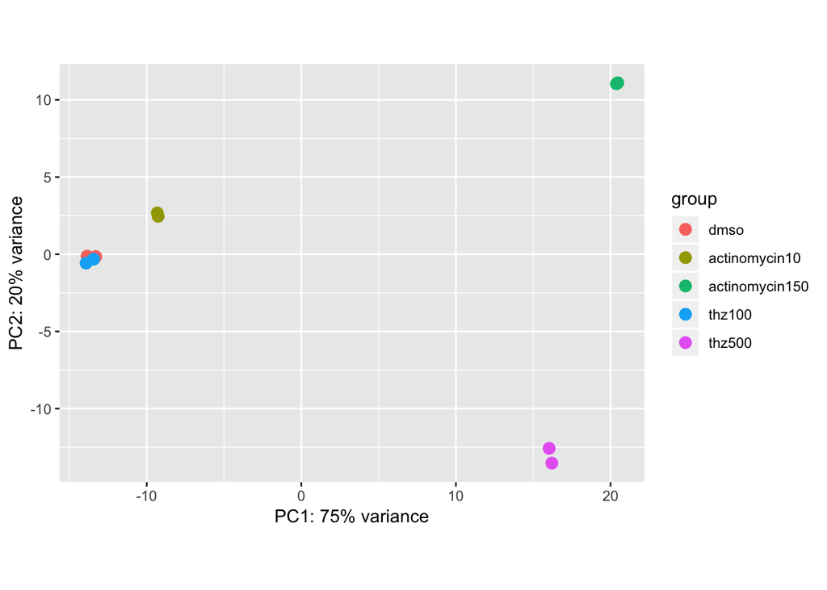

```r
plotPCA(dds_rlog, intgroup = "Treatment")
```

As you can see, the lower concentrations of THZ and actinomycin has no or very little effect.

We can also look at it using a correlation matrix and a heatmap.

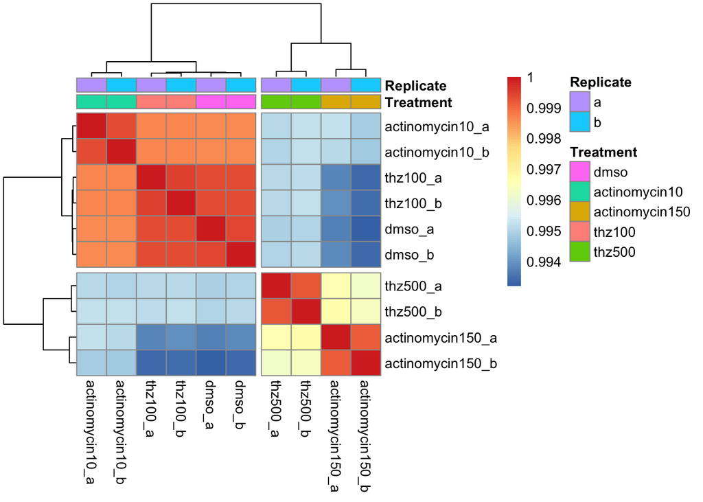

```r
matrix_correlation_rlog <- cor(matrix_counts_rlog)
pheatmap(
  matrix_correlation_rlog,
  cutree_rows = 2,
  cutree_cols = 2,
  annotation_col = table_samples
)
```

Therefore we should only focus on `thz500` and `actinomycin150` samples.

As you remember from earlier, we set `dmso` as the base level for all comparisons. Therefore, all differential expression is based on up- or downregulated based on gene expressions in DMSO-treated samples. This we can also see with the `resultsNames` command:

```r
resultsNames(dds)
```

```
## [1] "Intercept"                        "Treatment_actinomycin10_vs_dmso"
## [3] "Treatment_actinomycin150_vs_dmso" "Treatment_thz100_vs_dmso"
## [5] "Treatment_thz500_vs_dmso"
```

For downstream analysis, we define here 2 cutoffs: adjusted p-value (0.05) and fold change (1.5).

```r
p_value_cutoff <- 0.05
lfc_threshold <- log2(1.5)

lfc_lines <- c(-lfc_threshold, lfc_threshold)
```

Using these cutoffs, we extract differential expression information from our analysis. We also use independent hypothesis weighing [3] to increase the power of our statistical analysis.

```r
results_thz <- results(
  dds,
  name = "Treatment_thz500_vs_dmso",
  alpha = p_value_cutoff,
  lfcThreshold = lfc_threshold,
  filterFun = ihw,
  parallel = TRUE
)

summary(results_thz)
```

```
##
## out of 27442 with nonzero total read count
## adjusted p-value < 0.05
## LFC > 0.58 (up)    : 560, 2%
## LFC < -0.58 (down) : 2537, 9.2%
## outliers [1]       : 0, 0%
## [1] see 'cooksCutoff' argument of ?results
## see metadata(res)$ihwResult on hypothesis weighting
```

```r
results_actinomycin <- results(
  dds,
  name = "Treatment_actinomycin150_vs_dmso",
  alpha = p_value_cutoff,
  lfcThreshold = lfc_threshold,
  filterFun = ihw,
  parallel = TRUE
)

summary(results_actinomycin)
```

```
##
## out of 27442 with nonzero total read count
## adjusted p-value < 0.05
## LFC > 0.58 (up)    : 1162, 4.2%
## LFC < -0.58 (down) : 3629, 13%
## outliers [1]       : 0, 0%
## [1] see 'cooksCutoff' argument of ?results
## see metadata(res)$ihwResult on hypothesis weighting
```

The best visualization tool for these results is an MA plot.

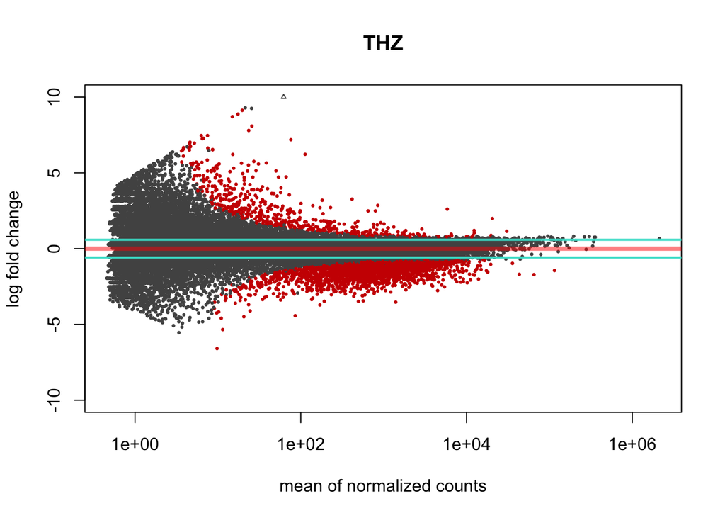

```r
plotMA(results_thz, ylim = c(-10, 10), alpha = 0.05, main = "THZ")
abline(h = lfc_lines, col = "turquoise", lwd = 2)
```

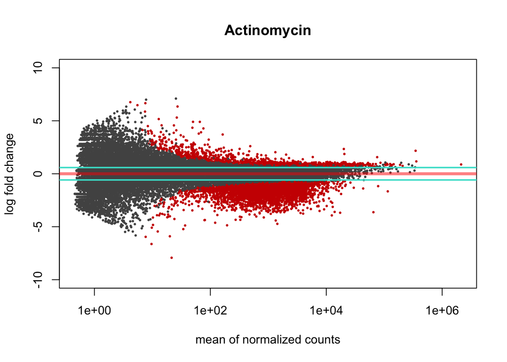

```r
plotMA(results_actinomycin, ylim = c(-10, 10), alpha = 0.05, main = "Actinomycin")
abline(h = lfc_lines, col = "turquoise", lwd = 2)
```

It looks nice but we see a lot of high fold changes on low expression genes, although they are not significant. In order to correct those, we apply *log fold change shrinkage* using the *apeglm* method [5].

```r
results_thz_lfcs <- lfcShrink(
  dds,
  res = results_thz,
  coef = "Treatment_thz500_vs_dmso", # note the difference name -> coef
  lfcThreshold = lfc_threshold,
  type = "apeglm",
  parallel = TRUE,
  quiet = TRUE
)
```

```
## computing FSOS 'false sign or small' s-values (T=0.585)
```

```r
summary(results_thz_lfcs)
```

```
##
## out of 27442 with nonzero total read count
## s-value < 0.005
## LFC > 0.58 (up)    : 751, 2.7%
## LFC < -0.58 (down) : 2909, 11%
```

```r
results_actinomycin_lfcs <- lfcShrink(
  dds,
  res = results_actinomycin,
  coef = "Treatment_actinomycin150_vs_dmso", # note the difference name -> coef
  lfcThreshold = lfc_threshold,
  type = "apeglm",
  parallel = TRUE,
  quiet = TRUE
)
```

```
## computing FSOS 'false sign or small' s-values (T=0.585)
```

```r
summary(results_actinomycin_lfcs)
```

```
##
## out of 27442 with nonzero total read count
## s-value < 0.005
## LFC > 0.58 (up)    : 1573, 5.7%
## LFC < -0.58 (down) : 3947, 14%
```

A new visualization looks like this:

```r
plotMA(results_thz_lfcs, ylim = c(-10, 11), main = "THZ, w/ LFC shrinkage")
```

```
## thresholding s-values on alpha=0.005 to color points
```

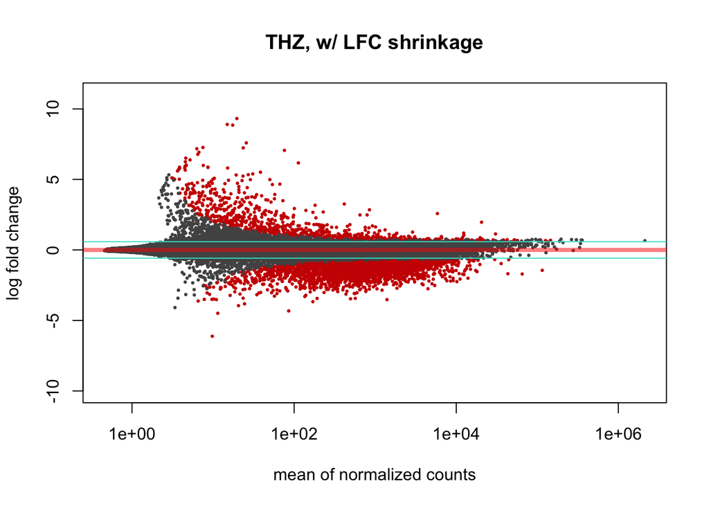

```r
abline(h = lfc_lines, col = "turquoise", lwd = 1)
```

```r
plotMA(results_actinomycin_lfcs, ylim = c(-10, 11), main = "Actinomycin, w/ LFC shrinkage")
```

```
## thresholding s-values on alpha=0.005 to color points
```

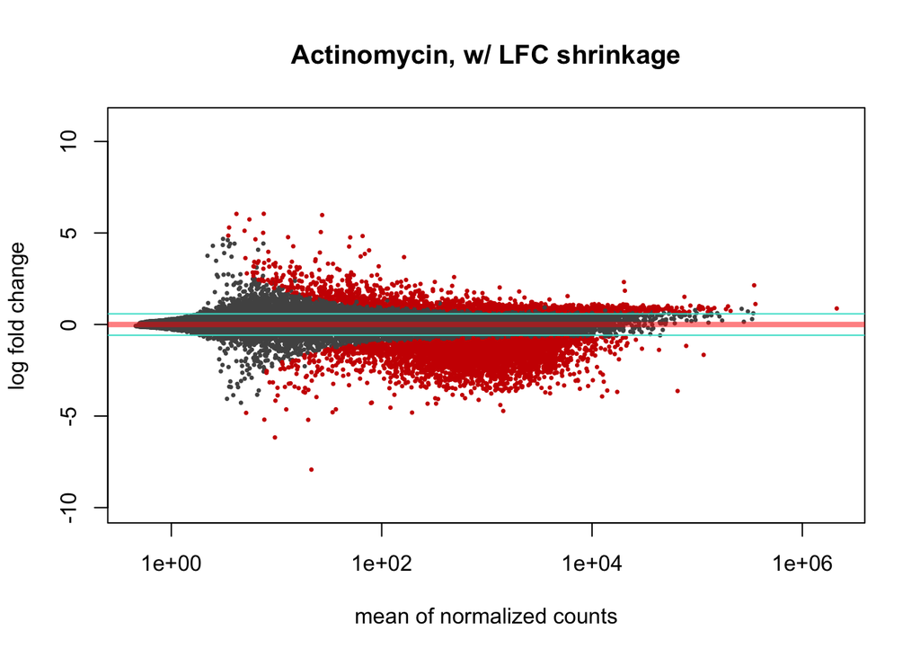

```r
abline(h = lfc_lines, col = "turquoise", lwd = 1)
```

An interesting gene in the context of chordoma is brachyury (TBXT). Let’s visualize it in these plots.

First we extract the relevant information from the LFC-shrunk results.

```r
TBXT_thz <- results_thz_lfcs["TBXT", 1:2]
TBXT_actinomycin <- results_actinomycin_lfcs["TBXT", 1:2]
```

Then we replot the MA plot and annotate TBXT on it.

```r
plotMA(results_thz_lfcs, ylim = c(-10, 10), main = "THZ")
```

```
## thresholding s-values on alpha=0.005 to color points
```

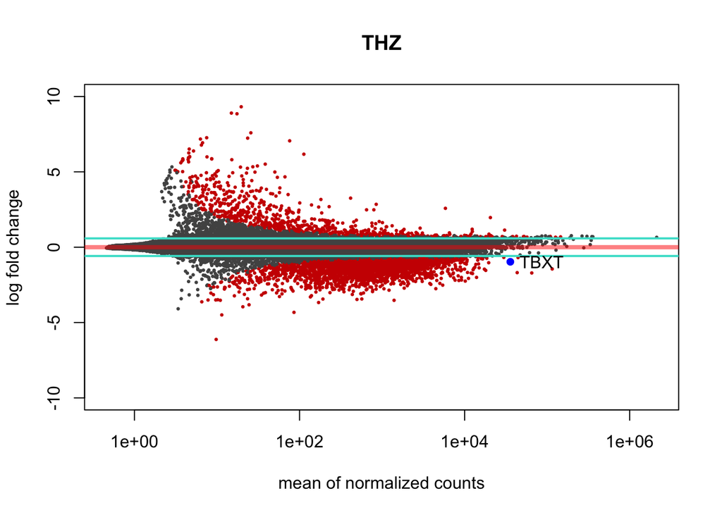

```r
abline(h = lfc_lines, col = "turquoise", lwd = 2)
points(x = TBXT_thz$baseMean, y = TBXT_thz$log2FoldChange, pch = 16, col = "blue")
text(x = TBXT_thz$baseMean + 50000, y = TBXT_thz$log2FoldChange, "TBXT")
```

```r
plotMA(results_actinomycin_lfcs, ylim = c(-10, 10), main = "Actinomycin")
```

```
## thresholding s-values on alpha=0.005 to color points
```

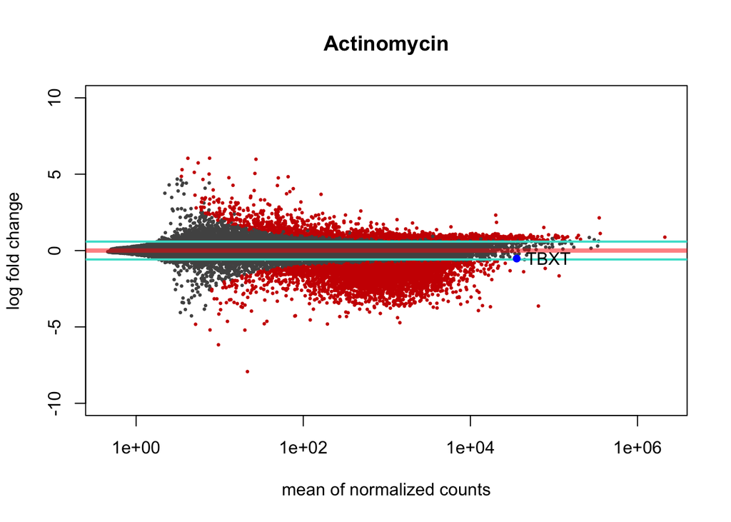

```r
abline(h = lfc_lines, col = "turquoise", lwd = 2)
points(x = TBXT_actinomycin$baseMean, y = TBXT_actinomycin$log2FoldChange, pch = 16, col = "blue")
text(x = TBXT_actinomycin$baseMean + 50000, y = TBXT_actinomycin$log2FoldChange, "TBXT")
```

And finally, we can look at the normalized counts for TBXT across all samples that we have.

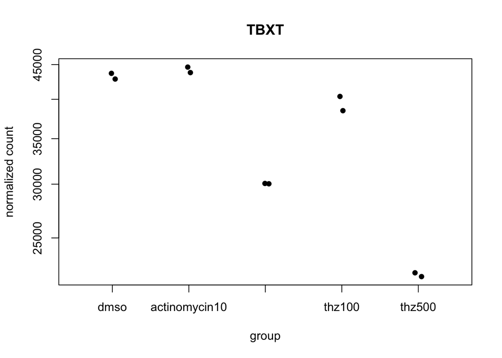

```r
plotCounts(dds, gene = "TBXT", intgroup = "Treatment", normalized = TRUE, pch = 16)
```

# 4 Additional resources

Please check out the [RNA-seq workflow](http://bioconductor.org/packages/release/workflows/vignettes/rnaseqGene/inst/doc/rnaseqGene.html) and [DESeq2 vignette](https://bioconductor.org/packages/release/bioc/vignettes/DESeq2/inst/doc/DESeq2.html) by Love *et al.* for detailed information on how to use DESeq2 in your analysis.

# References

1. Sharifnia T, Wawer M, Chen T, Huang Q, Weir B, Sizemore A, et al. Small-molecule targeting of brachyury transcription factor addiction in chordoma. Nature Medicine. 2019; doi:10.1038/s41591-018-0312-3

2. Love MI, Huber W, Anders S. Moderated estimation of fold change and dispersion for rna-seq data with deseq2. Genome Biology. 2014;15: 550. doi:10.1186/s13059-014-0550-8

3. Ignatiadis N, Klaus B, Zaugg J, Huber W. Data-driven hypothesis weighting increases detection power in genome-scale multiple testing. Nature Methods. 2016; doi:10.1038/nmeth.3885

4. Ignatiadis N, Huber W. Covariate-powered weighted multiple testing with false discovery rate control. arXiv. 2017; doi:arXiv:1701.05179

5. Zhu A, Ibrahim JG, Love MI. Heavy-tailed prior distributions for sequence count data: Removing the noise and preserving large differences. Bioinformatics. 2018; doi:10.1093/bioinformatics/bty895